# shim: A Simple HTTP Service for SciDB

B. W. Lewis blewis@paradigm4.com

11/9/2015

# What’s new (for SciDB 15.12)

## Support for the SciDB advanced I/O toolbox (*aio_tools*)

Use the `-a` command line flag, or add the line

```
aio=1
```

to the `/var/lib/shim/conf` file to save data using the SciDB aio_tools plugin (required).

## SciDB native authentication

But only for the `/execute_query` and `/cancel` services (the only services that really talk directly to SciDB). If you need to protect the other shim services, consider using digest authentication.

## Streaming and compression options no longer supported

The `execute_query` service no longer supports either option, if you use these options they will be ignored.

# Overview

Shim is a web service that exposes a very simple API for clients to interact with SciDB over HTTP connections. The API consists of a small number of services (described in detail below), including: `/new_session`, `/release_session`, `/execute_query`, `/cancel`, `/read_lines`, `/read_bytes`, `/upload_file`, `/upload`, `/version`.

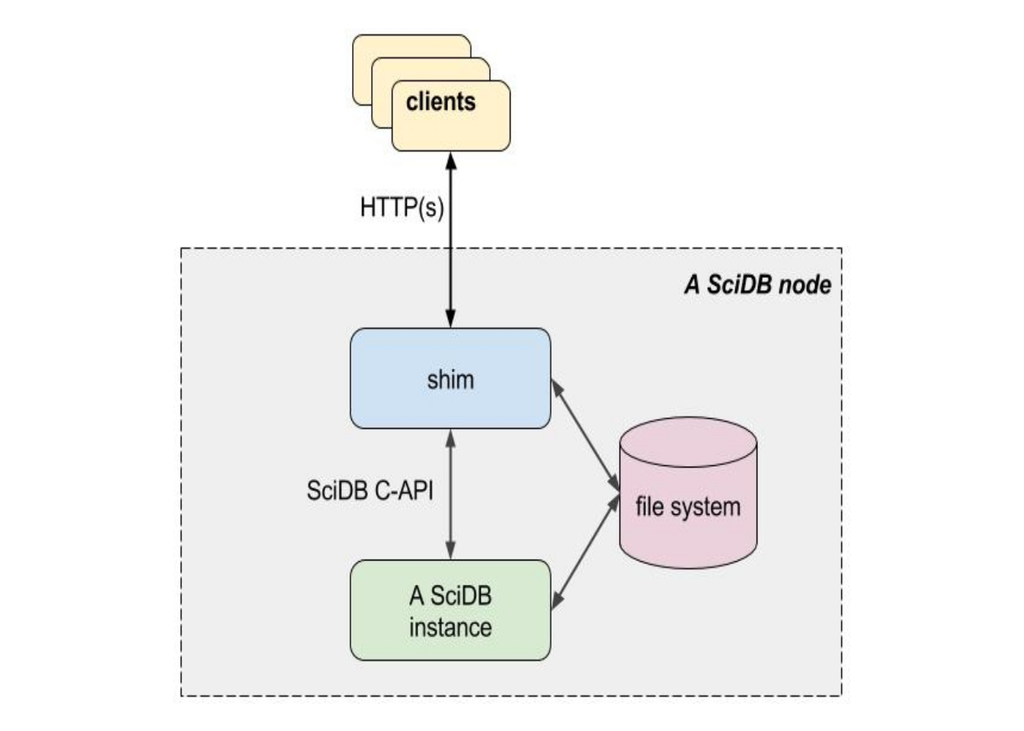

Shim clients begin by requesting a session ID from the service, then running a query and releasing the session ID when done. Session IDs are distinct from SciDB query IDs–a shim session ID groups a SciDB query together with server resources for input and output to the client.

# Configuration

Shim runs as a system service or can be invoked directly from the command line. See the shim manual page for command-line options (type `man shim` from a terminal). Service configuration is determined by the `/var/lib/shim/conf` configuration file. The default conf file is a sample that displays the default configuration options, which are listed as one key=value pair per line. Available options include:

```
#ports=8080,8083s
scidbport=1239
instance=0
tmp=/home/scidb/scidbdata/000/0/tmp
#user=root
#max_sessions=50
#timeout=60
#aio=1
```

Each option is described below.

## Ports and Network Interfaces

Shim listens on default ports 8080 (open, not encrypted), and 8083 (TLS encrypted) on all available network interfaces. Ports and listening interfaces are configured with the command line ‘-p’ option or with the ‘ports=’ option in the `/var/lib/shim/conf` file when shim is run as a service. The ports/interface specification uses the following syntax:

```
[address:]port[s][,[address:]port[s]][,...]
```

where:

- *address* indicates an optional I.P. address associated with a specific available network device, only specify this if you want to restrict shim to operate on a specific network device.
- *port* indicates a required available port number
- *s* is an optional single character ‘s’ suffix indicating that TLS/SSL should be used on that port.

Here are some examples of possible port configurations:

| 5555s |  | Listen only on port 5555 (TLS/SSL). |
| --- | --- | --- |
| 127.0.0.1:8080,1234s |  | List on port 8080 but only on the local loopback interface; listen on port 1234(TLS/SSL) on all interfaces. |

## SciDB Port

Shim runs on the same computer as a SciDB coordinator. Set the ‘scidbport’ option to select the coordinator database port to locally connect to. The default SciDB database port value is 1239 (see the SciDB configuration manual for more information). Since any SciDB instance can act as a query coordinator, it is possible to configure multiple shim services, for example one shim service per computer IP address.

## Instance

Set the SciDB instance number to use as a query coordinator. Make sure that this option is set together with the corresponding SciDB port number for the instance, and also set a corresponding temporary I/O location that the instance has read/write access to.

## Temporary I/O space

Shim’s default behavior caches the output of SciDB queries in files on the SciDB server; set that file directory location with the config file tmp option or the command-line -t argument. This temporary directory is also used to upload data from clients over the http connection for input into SciDB. Select a directory that is writable by the shim user (see the user option).

If you install shim from an RPM or Debian package as a service, the package will configure shim to use a SciDB data directory for temporary storage. You can edit the config file and restart shim to change that default.

## User

The user that the shim service runs under (shim can run as a non-root user).

## Max sessions

Set the maximum number of concurrent *shim* sessions, beyond which clients receive an HTTP ‘resource unavailable’ error.

## Timeout

Set the time in seconds after which an *inactive* session is considered timed out and a candidate for resource de-allocation. After sessions time out their resources are not freed unless the need to be to satisfy additional session demands. See the lazy timeout section below. Active sessions that are waiting on SciDB query results or transferring data are not subject to timeout and may run indefinitely.

## AIO plugin

Set `aio=1` in the config file to enable fast AIO save using the SciDB aio_tools plugin.

## TLS/SSL Certificate

Shim supports TLS/SSL encryption. Packaged versions of shim (RPM and Debian packages) generate a self-signed certificate and 4096-bit RSA key when shim is installed. The certificate is placed in `/var/lib/shim/ssl_cert.pem`. If you would prefer to use a different certificate, replace the automatically generated one.

# API Reference

Examples use the URL `http://localhost:8080` or `https://localhost:8083` (TLS) below. Parameters are required unless marked optional. All shim API services support CORS, see http://www.w3.org/TR/cors/ .

## Limits

HTTP 1.1 clients or greater are required.

All HTTP query parameters are passed to the service as string values. They are limited to a maximum of 4096 characters unless otherwise indicated (a notable exception is the SciDB query string parameter, limited to 262,144 characters).

HTTP query string parameters that represent numbers have limits. Unless otherwise indicated whole-number values (session ID, number of bytes to return, etc.) are interpreted by shim as signed 32-bit integers and are generally limited to values between zero and 2147483647. Values outside that range will result in an HTTP 400 error (invalid query).

## Basic digest access authentication

Shim supports basic digest access authentication. (See https://en.wikipedia.org/wiki/Digest_access_authentication and the references therein for a good description of the method.) Enable digest access authentication by creating an .htpasswd file in shim’s default `/var/lib/shim/wwwroot` directory (the .htpasswd file must be located in shim’s wwwroot directory, which can be changed with the command line switch -r). The format of the file must be:

```
username1:password1
username2:password2
...
```

Use plain text passwords in the file, and consider changing the permissions of the file to restrict access. Delete the .htpasswd file to disable basic digest access authentication.

Basic digest authentication works on plain or TLS-encrypted connections but can not be used in combination with SciDB authentication (see below).

## TLS/SSL encryption

Shim optionally exposes both open and encrypted (HTTPS/TLS) services. You can provide a signed certificate in the `/var/lib/shim` directory. A generic random unsigned certific is automatically generated for you if you install shim using either the .deb or .rpm package installer.

## SciDB authentication

See the `/execute_query` service documentation below.

## Generic API Workflow

```
/new_session
/execute_query
/read_lines or /read_bytes
/release_session
```

## API Service Endpoints

The R examples below use the `httr` package. We try to illustrate API calls with real examples using either curl or R. See https://github.com/Paradigm4/shim/tree/master/tests for additional examples.

### **/version**

DESCRIPTION

Print the shim code version string

METHOD

GET

PARAMETERS

RESPONSE

**Success** HTTP 200 and text version string value in text/plain payload

EXAMPLE (curl)

```bash
curl -f -s http://localhost:8080/version
```

```
16.9.0
```

EXAMPLE (R)

```r
httr::GET("http://localhost:8080/version")
```

```
Response [http://localhost:8080/version]
  Date: 2017-03-04 23:10
  Status: 200
  Content-Type: text/plain
  Size: 6 B
```

### **/new_session**

DESCRIPTION

Request a new HTTP session from the service.

METHOD

GET

PARAMETERS

RESPONSE

- Success: HTTP 200 and text session ID value in text/plain payload
- Failure (out of resources/server unavailable): HTTP 503
- Invalid request: HTTP 400

EXAMPLE (curl)

```bash
curl -s http://localhost:8080/new_session
```

```
21
```

EXAMPLE (R)

```r
id = httr::GET("http://localhost:8080/new_session")
(id = rawToChar(id$content))
```

```
[1] "22"
```

### **/release_session**

DESCRIPTION

Release an HTTP session.

METHOD

GET

PARAMETERS

- **id** an HTTP session ID obtained from `/new_session`

RESPONSE

Success: HTTP 200

Failure (Session not found): HTTP 404

Failure (invalid http query): HTTP 400

EXAMPLE (R)

```r
id = httr::GET("http://localhost:8080/new_session")
(id = rawToChar(id$content))
```

```
[1] "23"
```

```r
httr::GET(sprintf("http://localhost:8080/release_session?id=%s",id))
```

```
Response [http://localhost:8080/release_session?id=23]
  Date: 2017-03-04 23:10
  Status: 200
  Content-Type: text/plain
<EMPTY BODY>
```

EXAMPLE (curl)

```bash
s=`curl -s "http://localhost:8080/new_session"`
curl -s "http://localhost:8080/release_session?id=${s}"
```

### **/execute_query**

DESCRIPTION

Execute a SciDB AFL query.

METHOD

GET

PARAMETERS

- **id** an HTTP session ID obtained from `/new_session`
- **user** *optional* SciDB authentication user name (TLS connections only)
- **password** *optional* encoded SciDB authentication password (TLS connections only)
- **query** AFL query string, encoded for use in URL as required, limited to a maximum of 262,144 characters
- **save** optional SciDB save format string, limited to a maximum of 4096 characters; Save the query output in the specified format for subsequent download by `read_lines` or `read_bytes`. If the save parameter is not specified, don’t save the query output.
- **release** optional 0 or 1: if 1 then release_session as soon as query completes. The default value is 0 if not specified (see additional notes below).
- **prefix** *optional* semi-colon separated URL encoded AFL statements to precede **query** in the same SciDB connection context. Mainly used for SciDB namespace and role setting.

RESPONSE

Success: HTTP 200 text/plain (SciDB Query ID)

Failure (SciDB not available error): HTTP 503 text/plain (ERROR TEXT)

Failure (SciDB query error): HTTP 500 text/plain (SCIDB ERROR TEXT)

Failure (out of memory error): HTTP 507 text/plain (SCIDB ERROR TEXT)

Failure (Invalid session): HTTP 404

Failure (invalid http query): HTTP 400

Not authorized (encrypted only): HTTP 401

NOTES

Shim only supports AFL queries.

Remember to URL-encode the SciDB query string.

Specify optional user and password information for SciDB authentication. The password must be encoded as `base64( sha512("plain text password") )` – authentication requires a TLS encrypted connection.

500 and 503 errors result in removal of the web session ID and related resources (thus, `release_session` does not have to be called after such an error).

This method blocks until the query completes.

Do not specify the option release=1 when the save option is also set, or output will not be available to `read_bytes` or `read_lines`. Instead, explicitly call `release_session` after reading is complete.

EXAMPLE (R)

```r
# Obtain a shim session ID
id = httr::GET("http://localhost:8080/new_session")
session = rawToChar(id$content)

# Construct the query request
query = sprintf("http://localhost:8080/execute_query?id=%s&query=consume(list())&release=1",
                session)
ans = httr::GET(query)

# The response in this example is just the SciDB query ID:
(rawToChar(ans$content))
```

```
[1] "1488687009794278075"
```

EXAMPLE (curl)

```bash
s=`curl -s "http://localhost:8080/new_session"`
curl -s "http://localhost:8080/execute_query?id=${s}&query=consume(list())&release=1"
```

```
1488687009842888041
```

EXAMPLE w/ERROR (R)

```r
id = httr::GET("http://localhost:8080/new_session")
session = rawToChar(id$content)
query = sprintf("http://localhost:8080/execute_query?id=%s&query=consume(42)&release=1",
                session)
httr::GET(query)
```

```
Response [http://localhost:8080/execute_query?id=27&query=consume(42)&release=1]
  Date: 2017-03-04 23:10
  Status: 500
  Content-Type: text/html
  Size: 279 B
UserQueryException in file: src/query/parser/Translator.cpp function: ma...
Error id: scidb::SCIDB_SE_QPROC::SCIDB_LE_WRONG_OPERATOR_ARGUMENT2
Error description: Query processor error. Parameter must be array name o...
consume(42)
```

EXAMPLE using prefix to set namespace (curl)

See the `tests/scidb_auth_example.sh` file for a full example.

```bash
id=$(curl -s -k "https://${host}:${port}/new_session")
curl -f -s -k "https://${host}:${port}/execute_query?id=${id}&prefix=set_namespace('cazart')&query=list()&user=${USER}&password=${PASSWORD}&save=dcsv"
curl -f -s -k "https://${host}:${port}/read_lines?id=${id}&n=0"
curl -f -s -k "https://${host}:${port}/release_session?id=${id}"
```

See `/read_lines` and `/read_bytes` below for running queries that return results and downloading them.